# March 01-07

Yumou

2023-03-01

## Factor variables

what are the types of variables in the “fbi” data?

```r
library(classdata)
library(tidyverse)

str(fbi)
```

```
## tibble [19,476 × 8] (S3: tbl_df/tbl/data.frame)
##  $ state        : chr [1:19476] "Alabama" "Alabama" "Alabama" "Alabama" ...
##  $ state_id     : int [1:19476] 2 2 2 2 2 2 2 2 2 2 ...
##  $ state_abbr   : chr [1:19476] "AL" "AL" "AL" "AL" ...
##  $ year         : int [1:19476] 1983 1983 1983 1983 1983 1983 1983 1983 1983 1985 ...
##  $ population   : int [1:19476] 3959000 3959000 3959000 3959000 3959000 3959000 3959000 3959000 3959000 4021000 ...
##  $ type         : chr [1:19476] "homicide" "rape_legacy" "rape_revised" "robbery" ...
##  $ count        : int [1:19476] 364 931 NA 3895 11281 42485 94279 9126 981 396 ...
##  $ violent_crime: logi [1:19476] TRUE TRUE TRUE TRUE TRUE FALSE ...
```

```r
fbi1 = fbi
```

Make “year”, “state” and “type” as factor variables:

```r
fbi1$state = as.factor(fbi1$state)
fbi1$type.factor =  as.factor(fbi1$type)
fbi1$state_abbr = as.factor(fbi1$state_abbr)
fbi1$year.factor = as.factor(fbi1$year)
str(fbi1)
```

```
## tibble [19,476 × 10] (S3: tbl_df/tbl/data.frame)
##  $ state        : Factor w/ 52 levels "Alabama","Alaska",..: 1 1 1 1 1 1 1 1 1 1 ...
##  $ state_id     : int [1:19476] 2 2 2 2 2 2 2 2 2 2 ...
##  $ state_abbr   : Factor w/ 52 levels "AK","AL","AR",..: 2 2 2 2 2 2 2 2 2 2 ...
##  $ year         : int [1:19476] 1983 1983 1983 1983 1983 1983 1983 1983 1983 1985 ...
##  $ population   : int [1:19476] 3959000 3959000 3959000 3959000 3959000 3959000 3959000 3959000 3959000 4021000 ...
##  $ type         : chr [1:19476] "homicide" "rape_legacy" "rape_revised" "robbery" ...
##  $ count        : int [1:19476] 364 931 NA 3895 11281 42485 94279 9126 981 396 ...
##  $ violent_crime: logi [1:19476] TRUE TRUE TRUE TRUE TRUE FALSE ...
##  $ type.factor  : Factor w/ 9 levels "aggravated_assault",..: 4 7 8 9 1 3 5 6 2 4 ...
##  $ year.factor  : Factor w/ 42 levels "1979","1980",..: 5 5 5 5 5 5 5 5 5 7 ...
```

Boxplots for factor variables:

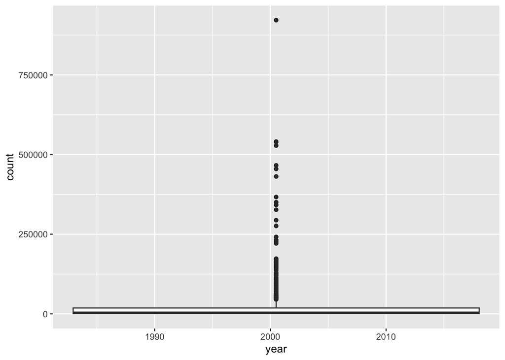

```r
twoyear = dplyr::filter(fbi1, year %in% c(1981, 2020))

ggplot(twoyear, aes(x = year, y = count)) + geom_boxplot()
```

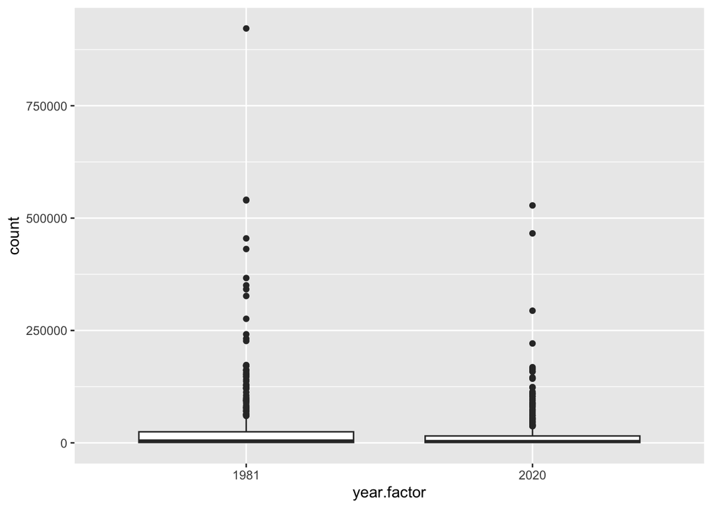

```r
ggplot(twoyear, aes(x = year.factor, y = count)) + geom_boxplot()
```

Transform factor to numeric variable

```r
b1 = as.numeric(fbi1$year.factor) # not working

b2 = as.numeric(as.character(fbi1$year.factor)) # works
```

## levels of factors

Manually reorder the levels of a factor (two ways):

```r
levels(fbi1$type.factor)
```

```
## [1] "aggravated_assault"  "arson"               "burglary"
## [4] "homicide"            "larceny"             "motor_vehicle_theft"
## [7] "rape_legacy"         "rape_revised"        "robbery"
```

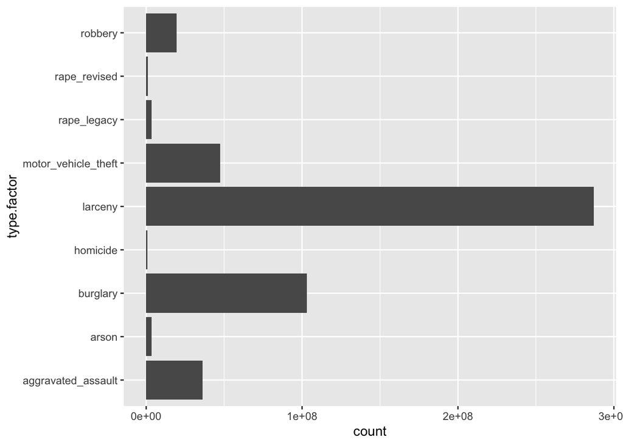

```r
ggplot(fbi1, aes(x = type.factor)) + geom_bar(aes(weight = count)) + coord_flip() # not ordered
```

```r
fbi1$type.reorder = factor(fbi1$type,
                  levels = c("larceny", "burglary",
                     "motor_vehicle_theft", "aggravated_assault",
                     "robbery", "arson", "rape_legacy", "rape_revised", "homicide")
                  )
levels(fbi1$type.reorder)
```

```
## [1] "larceny"             "burglary"            "motor_vehicle_theft"
## [4] "aggravated_assault"  "robbery"             "arson"
## [7] "rape_legacy"         "rape_revised"        "homicide"
```

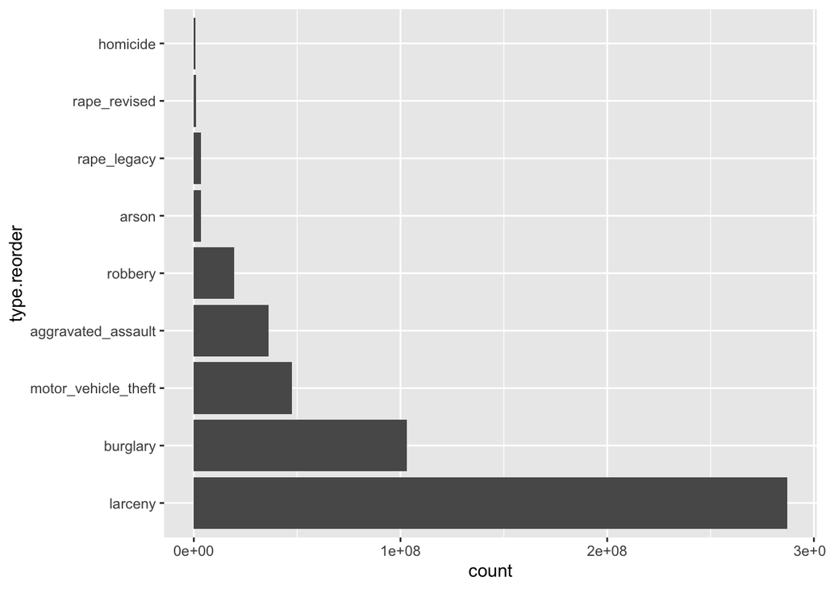

```r
ggplot(fbi1, aes(x = type.reorder)) + geom_bar(aes(weight = count)) + coord_flip() # works
```

The following code would not work:

```r
fbi1$type.reorder.2 = fbi1$type.factor
levels(fbi1$type.reorder.2)
```

```
## [1] "aggravated_assault"  "arson"               "burglary"
## [4] "homicide"            "larceny"             "motor_vehicle_theft"
## [7] "rape_legacy"         "rape_revised"        "robbery"
```

```r
levels(fbi1$type.reorder.2) = c("LA", "BU",
                     "MVT", "AS",
                     "RB", "AR", "RL", "RV", "HO")
levels(fbi1$type.reorder.2)
```

```
## [1] "LA"  "BU"  "MVT" "AS"  "RB"  "AR"  "RL"  "RV"  "HO"
```

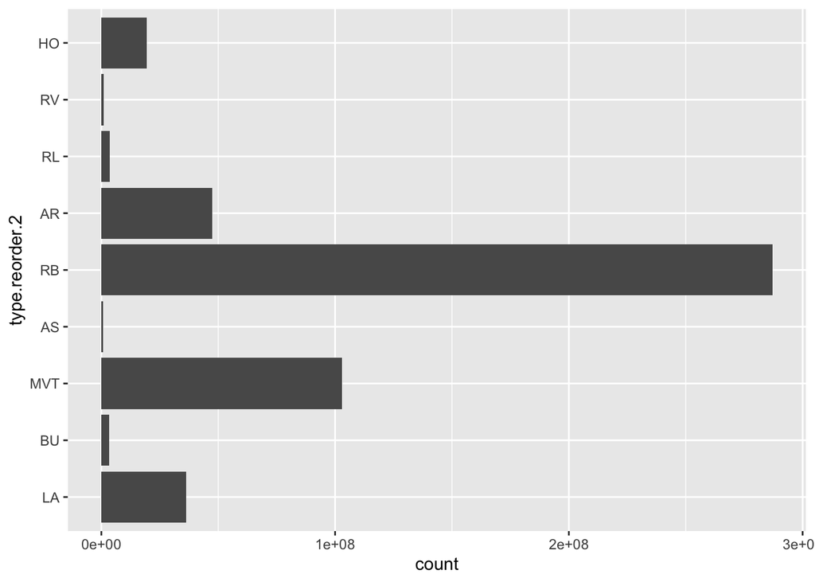

```r
ggplot(fbi1, aes(x = type.reorder.2)) + geom_bar(aes(weight = count)) + coord_flip() # not working
```

“reorder()” function:

```r
levels(reorder(fbi1$type, fbi1$count, na.rm = TRUE))
```

```
## [1] "homicide"            "arson"               "rape_legacy"
## [4] "rape_revised"        "robbery"             "aggravated_assault"
## [7] "motor_vehicle_theft" "burglary"            "larceny"
```

```r
A1 = dplyr::filter(fbi, type == "aggravated_assault")
mean(A1$count, na.rm = TRUE)
```

```
## [1] 16751.17
```

```r
A2 = dplyr::filter(fbi, type == "arson")
mean(A2$count, na.rm = TRUE)
```

```
## [1] 1553.908
```

```r
A3 = dplyr::filter(fbi, type == "robbery")
mean(A3$count, na.rm = TRUE)
```

```
## [1] 9007.005
```

```r
# reorder based on the summation of "count" variable
levels(reorder(fbi1$type, fbi1$count, FUN = sum, na.rm = TRUE))
```

```
## [1] "homicide"            "rape_revised"        "arson"
## [4] "rape_legacy"         "robbery"             "aggravated_assault"
## [7] "motor_vehicle_theft" "burglary"            "larceny"
```

## Practice for factor variable

1. Introduce a rate of the number of reported offenses by population into the fbi data. You could use the Ames standard to make values comparable to a city of the size of Ames (population ~70,000).

```r
fbi1$rate = fbi1$count / fbi1$population * 70000
```

2. Plot boxplots of crime rates by different types of crime. How can you make axis text legible?

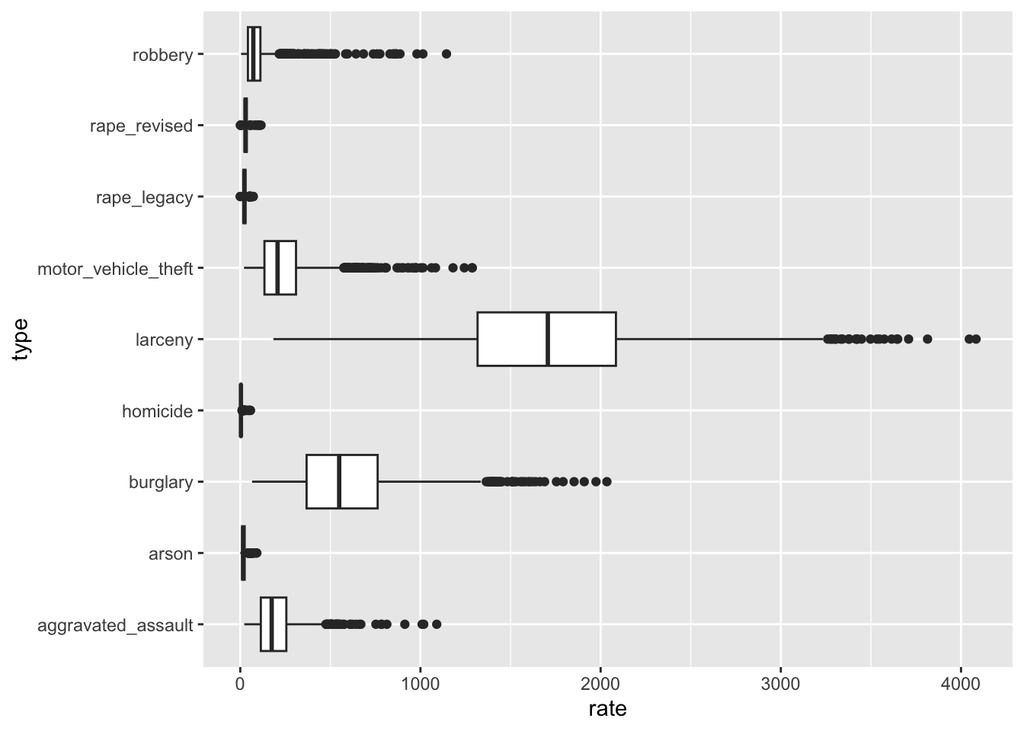

```r
ggplot(fbi1, aes(x = type, y = rate)) + geom_boxplot() + coord_flip()
```

3. Reorder the boxplots of crime rates, such that the boxplots are ordered by their medians.

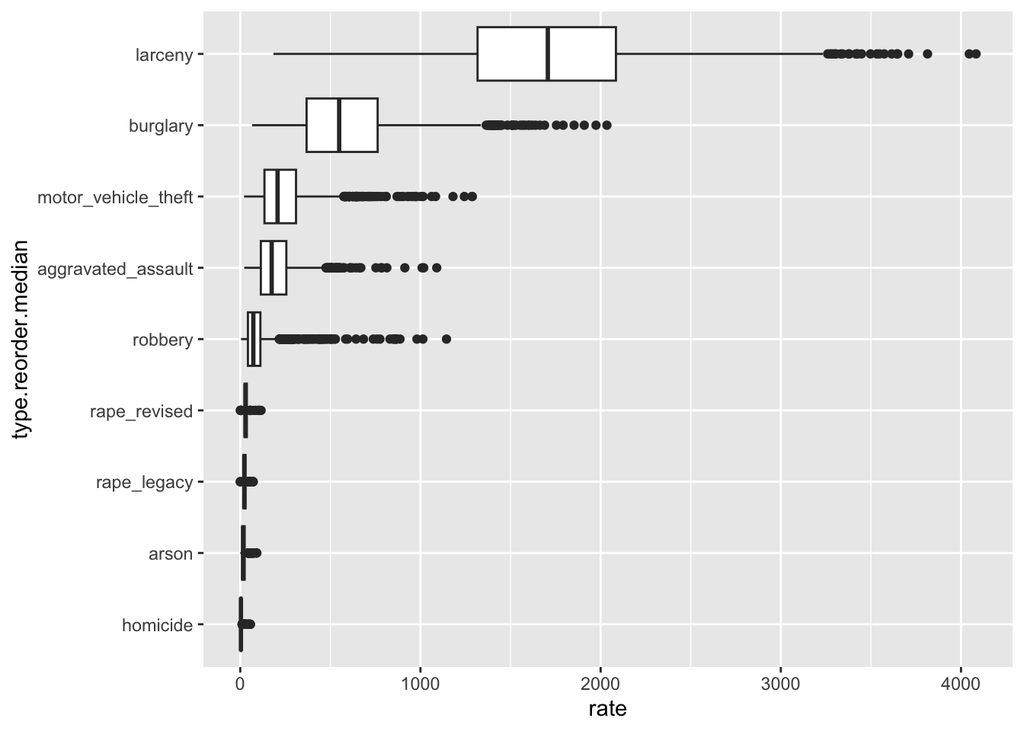

```r
fbi1$type.reorder.median = reorder(fbi1$type, fbi1$count, FUN = median, na.rm = TRUE)

ggplot(fbi1, aes(x = type.reorder.median, y = rate)) + geom_boxplot() + coord_flip()
```

4. For one type of crime (subset or filter) plot boxplots of rates by state, reorder boxplots by median crime rates

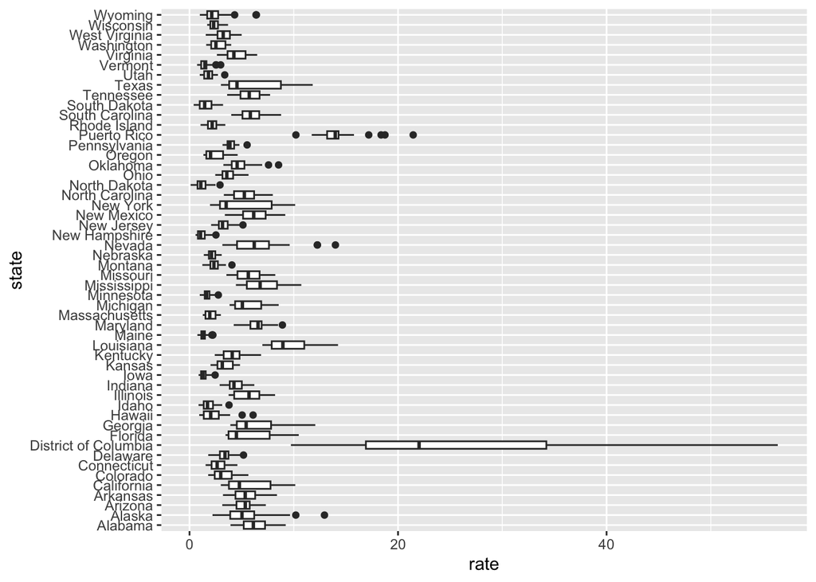

```r
fbi2 = dplyr::filter(fbi1, type == "homicide")

ggplot(fbi2, aes(x = state, y = rate)) + geom_boxplot() + coord_flip()
```

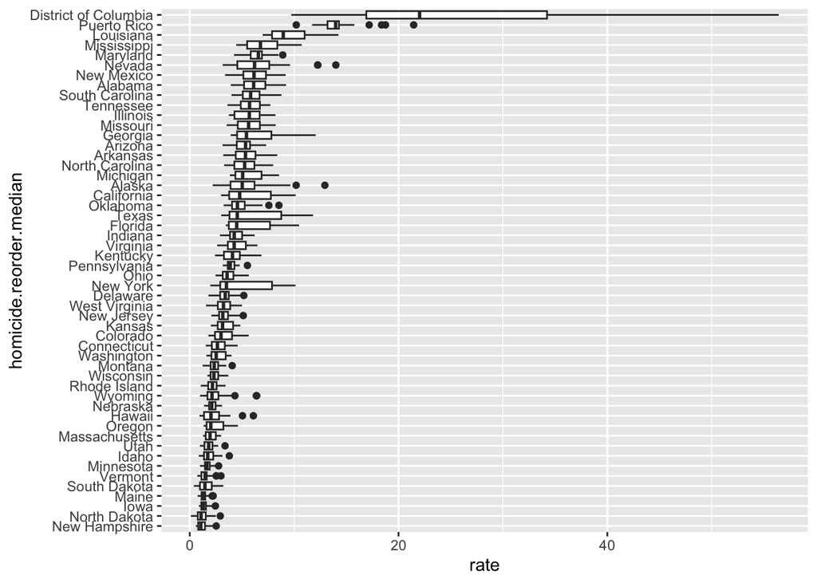

```r
fbi2$homicide.reorder.median = reorder(fbi2$state, fbi2$rate, FUN = median, na.rm = TRUE)

ggplot(fbi2, aes(x = homicide.reorder.median, y = rate)) + geom_boxplot() + coord_flip()
```

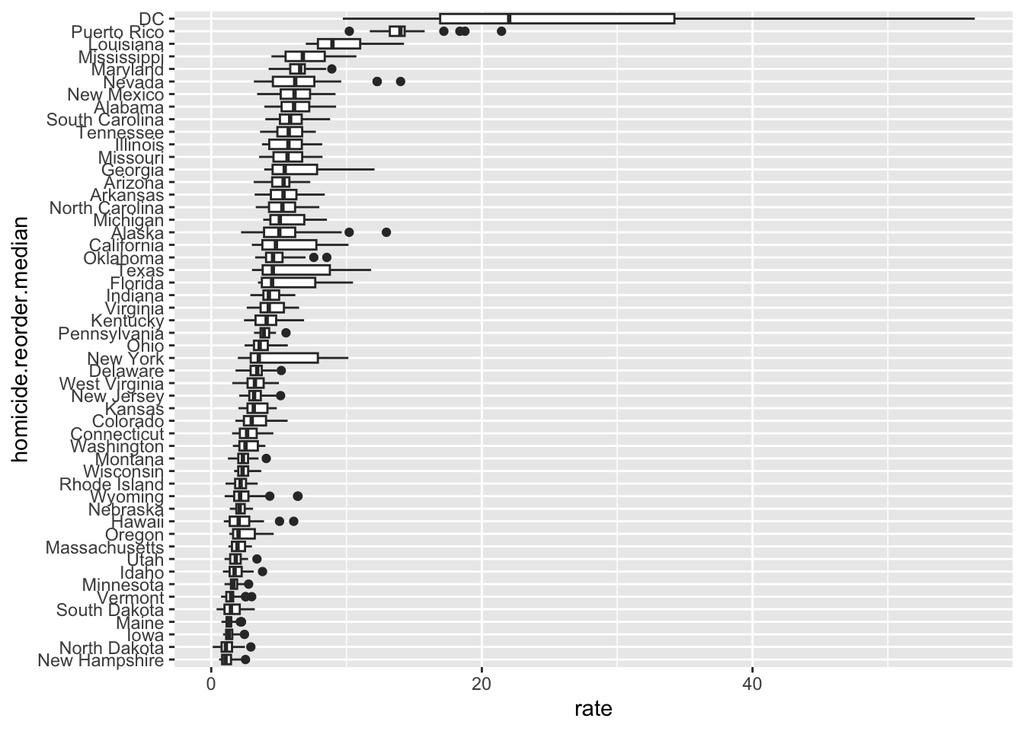

```r
# change "District of Columbia" to "DC"
levels(fbi2$homicide.reorder.median)[52] = "DC"
ggplot(fbi2, aes(x = homicide.reorder.median, y = rate)) + geom_boxplot() + coord_flip()
```

## Plots for factor variables

Difference between the mappings of “color” and “fill”:

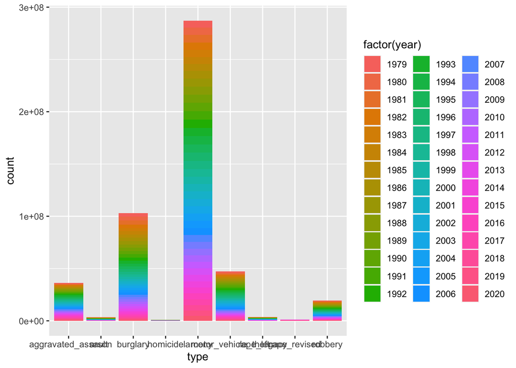

```r
ggplot(fbi, aes(x = type, fill=factor(year))) + geom_bar(aes(weight = count))
```

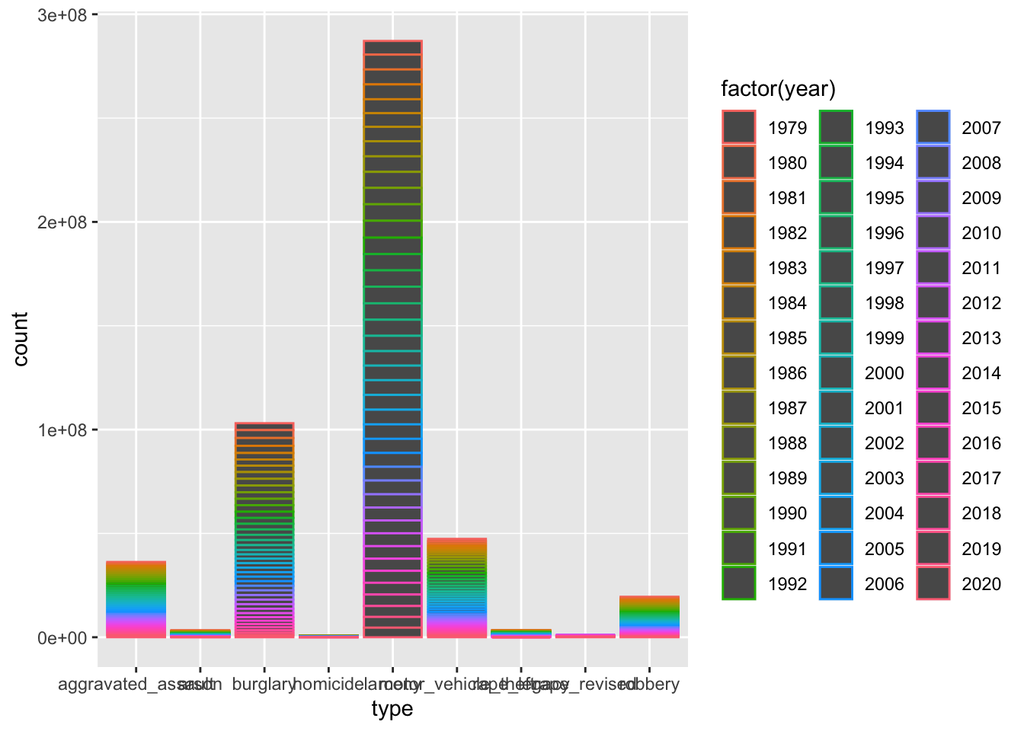

```r
ggplot(fbi, aes(x = type, color=factor(year))) + geom_bar(aes(weight = count))
```

## “Titanic” data example

1. Draw a barchart of Gender. Interpret.

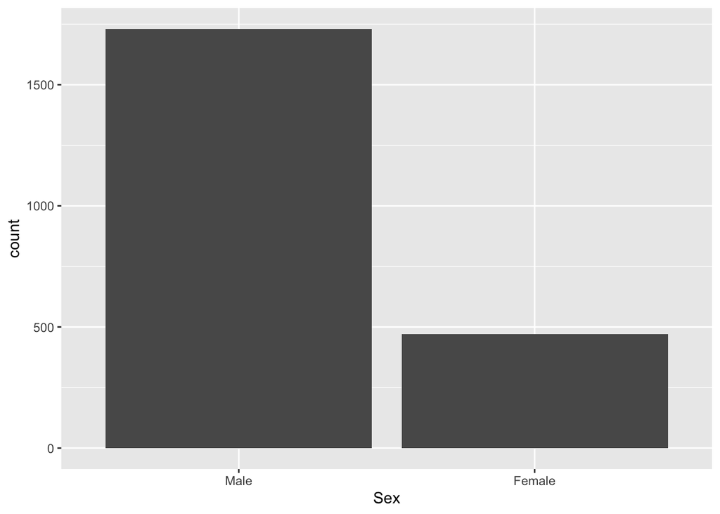

```r
ggplot(titanic, aes(x = Sex)) + geom_bar()
```

2. Map survival to fill color in the barchart of Gender. Interpret.

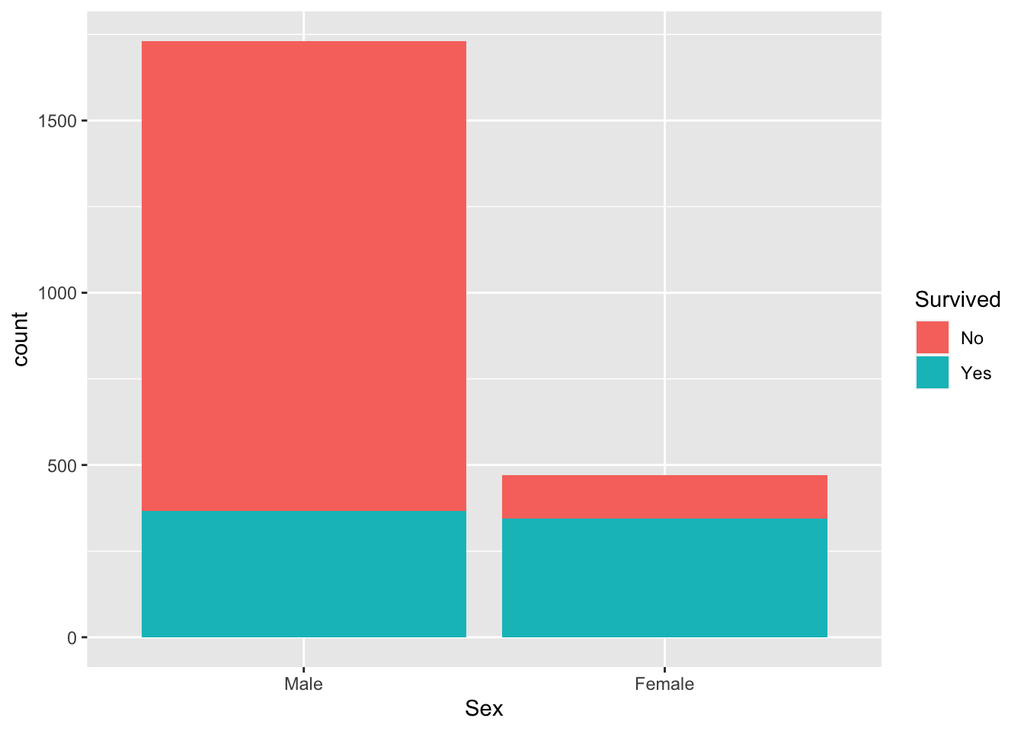

```r
ggplot(titanic, aes(x = Sex, fill = Survived)) + geom_bar()
```

3. In the previous barchart change the position parameter to “fill”. Interpret.

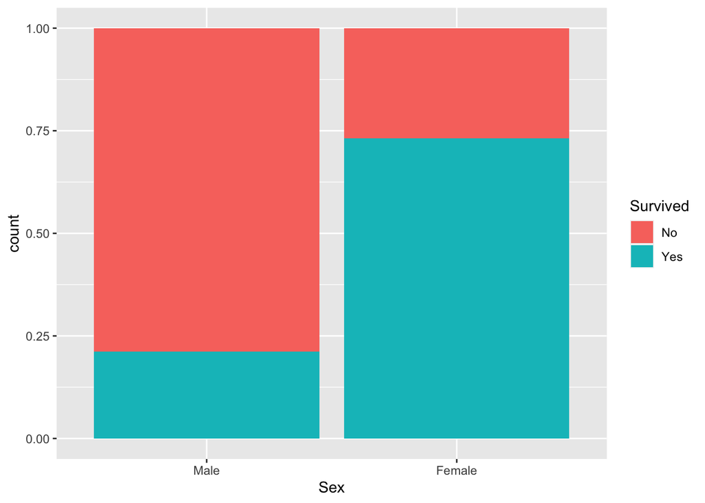

```r
ggplot(titanic, aes(x = Sex, fill = Survived)) + geom_bar(position = "fill")
```

4. Other options for position parameter:

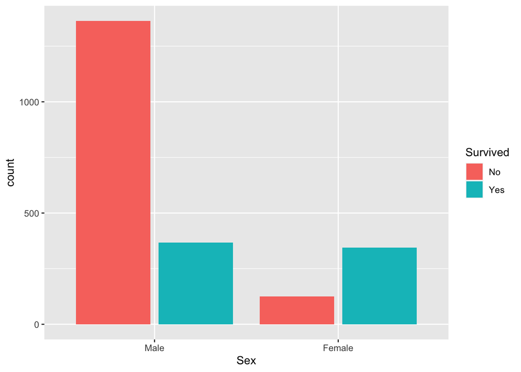

```r
ggplot(titanic, aes(x = Sex, fill = Survived)) + geom_bar(position = "dodge2")
```

## Practice questions

1. In the above plots, we cannot see the relationship between class and gender since we make barplot separately for each class. How to show the relationship between class, gender and survive?

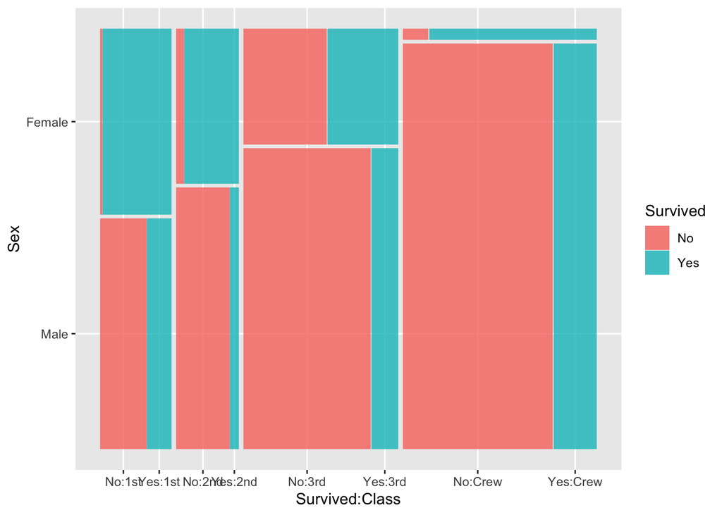

```r
library(ggmosaic)
ggplot(data = titanic) +
  geom_mosaic(aes(x = product(Sex, Class), fill=Survived, weight=1))
```

2. Choose California and New York, and year 1981 and 2016. Compare State, year and type by the crime rate.

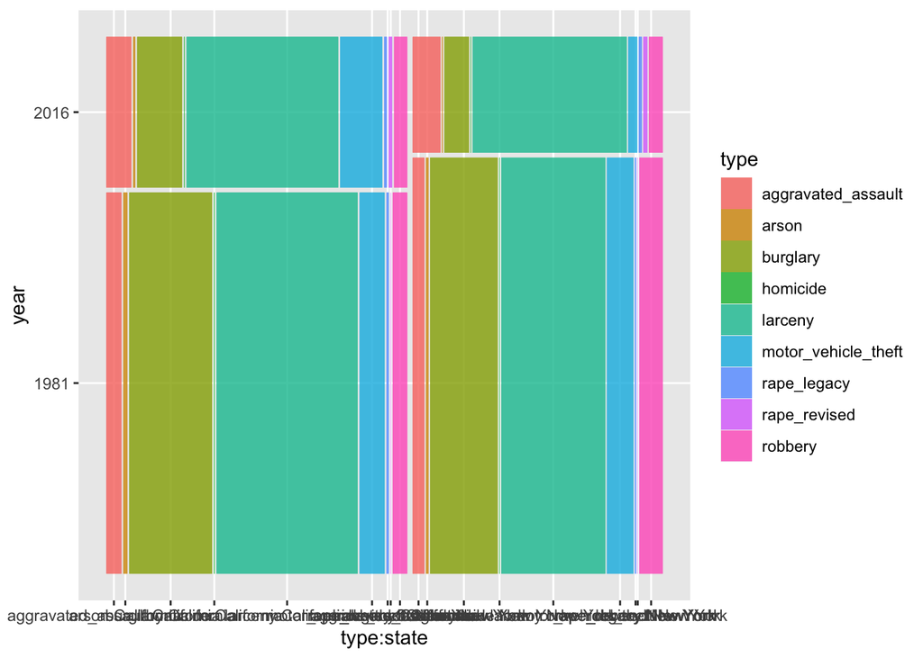

```r
library(tidyverse)
fbi.compare = dplyr::filter(fbi, year %in% c(1981, 2016), state %in% c("California", "New York"))

fbi.compare$crime.rate = fbi.compare$count / fbi.compare$population
fbi.compare$year = factor(fbi.compare$year)
fbi.compare$state = factor(fbi.compare$state)
fbi.compare$type = factor(fbi.compare$type)

ggplot(fbi.compare) +
  geom_mosaic(aes(x = product(year, state),
                  fill = type,
                  weight = crime.rate))
```

3. Rename and reorder the factors appropriately

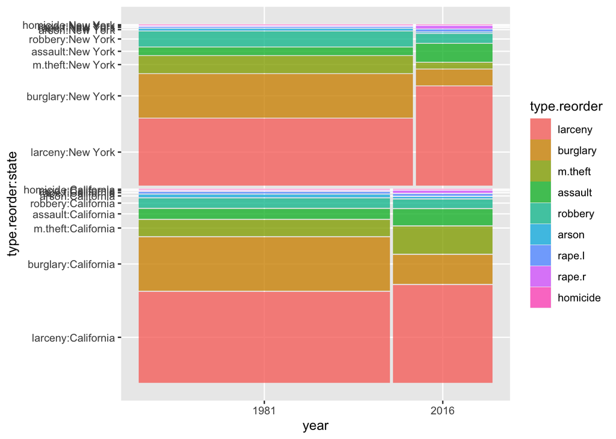

```r
levels(fbi.compare$type)[1] = "assault"
levels(fbi.compare$type)[6] = "m.theft"
levels(fbi.compare$type)[7] = "rape.l"
levels(fbi.compare$type)[8] = "rape.r"

fbi.compare$type.reorder = fbi.compare$type
fbi.compare$type.reorder = factor(fbi.compare$type,
                                  levels = c("larceny", "burglary",
                                             "m.theft", "assault",
                                             "robbery", "arson", "rape.l",
                                             "rape.r", "homicide"))

ggplot(fbi.compare) +
  geom_mosaic(aes(x = product(year, state),
                  fill = type.reorder,
                  weight = crime.rate)) + coord_flip()
```

## radar plot

```r
library(reshape2)
mean.iris =
    iris %>%
    group_by(Species) %>%
    summarise_all("mean") %>%
    melt()
```

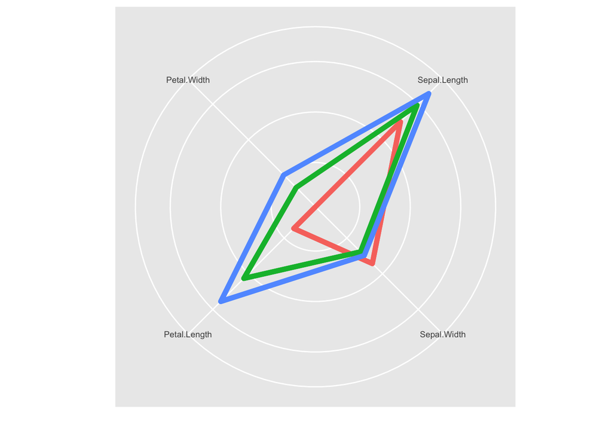

```r
coord_radar <- function (theta = "x", start = 0, direction = 1)
{
    theta <- match.arg(theta, c("x", "y"))
    r <- if (theta == "x")
        "y"
    else "x"
    ggproto("CordRadar", CoordPolar, theta = theta, r = r, start = start,
        direction = sign(direction),
        is_linear = function(coord) TRUE)
}

ggplot(mean.iris, aes(x = variable, y = value)) +
  geom_polygon(aes(group = Species, color = Species), fill = NA, size = 2) +
  geom_line(aes(group = Species, color = Species), size = 2) +
  theme(strip.text.x = element_text(size = rel(0.8)),
        axis.text.x = element_text(size = rel(0.8)),
        axis.ticks.y = element_blank(),
        axis.text.y = element_blank()) +
  xlab("") + ylab("") +
  guides(color = "none") +
  coord_radar()
```

## Pracice question

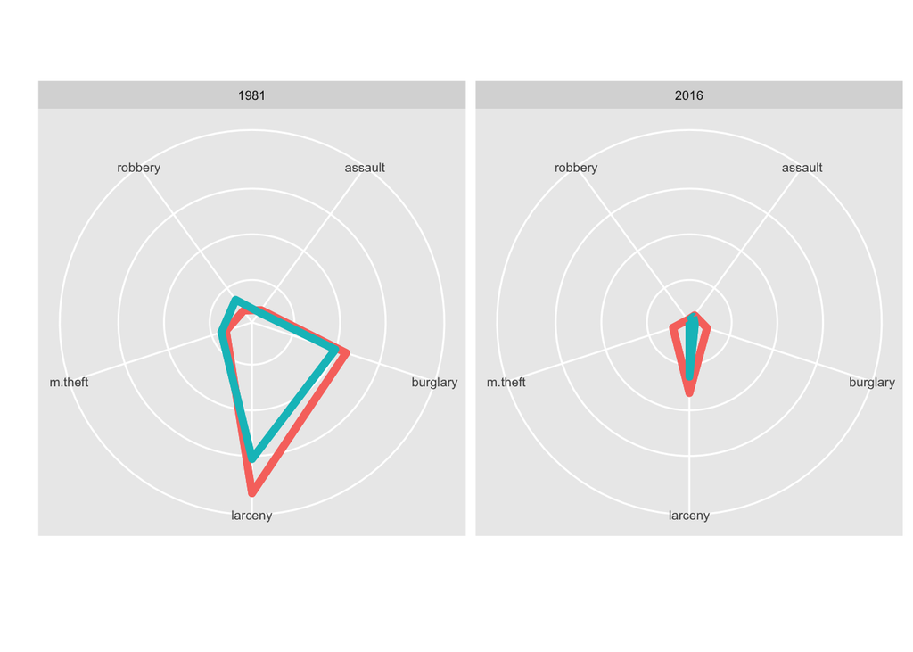

```r
fbi.compare.1 = dplyr::filter(fbi.compare, type != "rape.l", type != "rape.r", type != "homicide", type != "arson")
fbi.compare.1$type = as.character(fbi.compare.1$type) %>% as.factor()
fbi.compare.1 = fbi.compare.1 %>% select(state, year, type, crime.rate)

ggplot(fbi.compare.1, aes(x = type, y = crime.rate)) +
  geom_polygon(aes(group = state, color = state), fill = NA, size = 2) +
  geom_line(aes(group = state, color = state), size = 2) +
  facet_wrap(~year) +
  theme(strip.text.x = element_text(size = rel(0.8)),
        axis.text.x = element_text(size = rel(0.8)),
        axis.ticks.y = element_blank(),
        axis.text.y = element_blank()) +
  xlab("") + ylab("") +
  guides(color = "none") +
  coord_radar()
```

## ‘dplyr’ package

### pipe operator ‘%>%’

Let $f(x) = x^2 + 1$, and $g(x, y) = x + y^2$. Use the pipe oprator to calculate $g(f(1), 2)$.

```r
library(dplyr)

f1 = function(x){
  return(x^2 + 1)
}

g1 = function(x, y){
  return(x + y^2)
}

g1(f1(1), 2)
```

```
## [1] 6
```

```r
1 %>% f1() %>% g1(2)
```

```
## [1] 6
```

How about $g(3, f(1))$? This can not be computed using the pipe operator

```r
g1(3, f1(1))
```

```
## [1] 7
```

```r
1 %>% f1() %>% g1(3)
```

```
## [1] 11
```

Let $h(x) = x^3$. Calculate $h(f(1))$?

```r
h1 = function(x){
  return(x^3)
}

1 %>% f1() %>% h1()
```

```
## [1] 8
```